# Carving out the AutoML niche from Kaggle Survey

### Start

```r
library(tidyverse)
library(highcharter)
library(scales)
library(cowplot)
library(viridis)
library(wordcloud)
library(tidytext)
library(RColorBrewer)
library(ggrepel)

pal <- brewer.pal(9,"BuGn")
```

```r
# loosely based on @kailex's code snippet

make_multi_automl_plot <- function(start = 'Q9_Part_1', end = "Q9_Part_8") {

  survey_aml %>%
    filter(!is.na(automl)) %>%
    select(start:end,automl) %>%
    pivot_longer(cols = start:end, values_to = "Edu") %>%
    drop_na() %>%
    select(-name) %>%
    filter(Edu != "None") %>%
    group_by(Edu, automl) %>%
    summarize(freq = n()) %>%
    ungroup() %>%
    group_by(Edu) %>%
    mutate(tot = sum(freq)) %>%
    ungroup() %>% #View()
    ggplot(aes(reorder_within(automl, -freq, Edu), y=freq, fill = factor(Edu))) +
    geom_bar(stat = "identity") +
    scale_x_reordered() +
    facet_wrap(~ Edu, scales = "free") +
     scale_fill_viridis(discrete = TRUE, alpha=0.7, option="D") +
    theme_minimal() +
    labs(x = "", y = "") +
    theme(axis.text.x = element_text(angle = 45, hjust = 1), legend.position="none") +
    geom_label_repel(aes(label = paste0(freq, " - ", round(freq/tot*100), "%")),
                   colour = "gray20",
                   size=2.5, vjust = -0.1,
    nudge_y      = 0.25,
    direction    = "y",
    angle        = 90,
    segment.size = 0.2,
    fill = "white"
  )
}

make_single_automl_plot <- function(col = "Q9") {

  survey_aml %>%
    filter(!is.na(automl)) %>%
    select(col,automl) %>%
   # pivot_longer(cols = start:end, values_to = "Edu") %>%
    #drop_na() %>%
    #select(-name) %>%
    rename(Edu = col) %>%
    filter(Edu != "None") %>%
    group_by(Edu, automl) %>%
    summarize(freq = n()) %>%
    ungroup() %>%
    group_by(Edu) %>%
    mutate(tot = sum(freq)) %>%
    ungroup() %>% #View()
    ggplot(aes(reorder_within(automl, -freq, Edu), y=freq, fill = factor(Edu))) +
    geom_bar(stat = "identity") +
    scale_x_reordered() +
    facet_wrap(~ Edu, scales = "free") +
    scale_fill_viridis(discrete = TRUE, alpha=0.7, option="D") +
    theme_minimal() +
    labs(x = "", y = "") +
    theme(axis.text.x = element_text(angle = 45, hjust = 1), legend.position="none") +
    geom_label_repel(aes(label = paste0(freq, " - ", round(freq/tot*100), "%"), group = factor(Edu)),
                   colour = "gray20",
                   size=2.5, vjust = -0.1,
    nudge_y      = 0.25,
    direction    = "y",
    angle        = 90,
    segment.size = 0.2,
    fill = "white"
  )

}
```

```r
#list.files(path = "../input/kaggle-survey-2019/")

path_kaggle = "../input/kaggle-survey-2019/multiple_choice_responses.csv"

path_local = "multiple_choice_responses.csv"


survey <- read_csv(path_local, col_types = cols())  %>%
  slice(2:n())
```

```r
dim(survey)
```

```
## [1] 19717   246
```

### Identifying AutoML Niche

We’re trying to create a `flag` where if the respondent has answered any AutoML tool for `Q33` (other than `None`) then they are part of AutoML Niche (`True`) and if not, they’re not (`False`)

```r
survey %>%
    bind_cols(
      survey %>%
        select(Q33_Part_1:Q33_Part_12) %>%
        replace(is.na(.), 1) %>%
        mutate_all(funs(as.numeric(.))) %>%
        mutate(sum = rowSums(.[c(1:10,12)]))  %>%
        mutate(automl = ifelse(is.na(Q33_Part_11),
                               FALSE,
                               ifelse(is.na(sum),TRUE,NA))) %>%
        select(automl)
    ) -> survey_aml
```

# AutoMl Niche Stats

Only 9% of the entire survey respondents are part of AutoML Niche. While 26% explicitly mentioned they don’t use any AutoML, 64% of respondents didn’t care to answer this.

```r
survey_aml %>%
  count(automl) %>%
  mutate(percent = round(n / sum(n),2)*100) %>%
  mutate(automl = ifelse(is.na(automl),"I didn't care to respond",automl)) %>%
  rename('automl_niche' ='automl'  )
```

```
## # A tibble: 3 x 3
##   automl_niche                 n percent
##   <chr>                    <int>   <dbl>
## 1 FALSE                     5175      26
## 2 TRUE                      1840       9
## 3 I didn't care to respond 12702      64
```

Thus going forward, we’ll use only the cases where they’re either part of (`True`) of AutoML Niche or Not (`False`) - leaving out the ones that didn’t respond any

# Gender

26% of male respondents are part of AutoML Niche while 25% of Female respondents are part of it. It doesn’t strike any significant difference in the type of gender and being AutoML enthusiast.

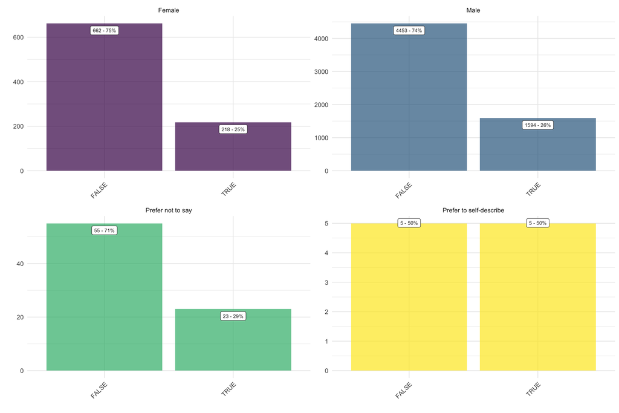

```r
make_single_automl_plot("Q2")
```

# Favorite media sources that report on data science topics

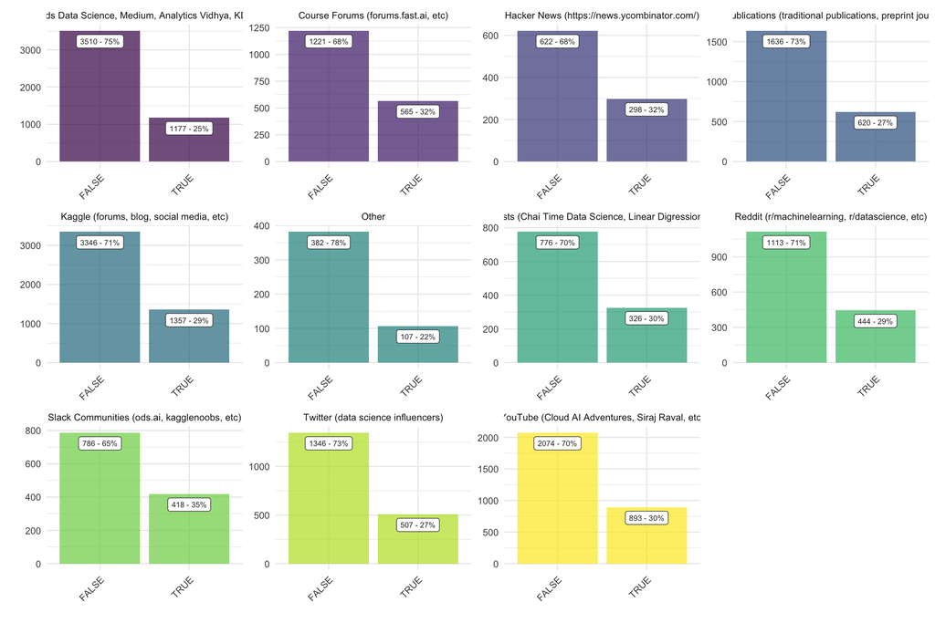

```r
make_multi_automl_plot("Q12_Part_1","Q12_Part_12")
```